# COMPSCIX 415.2 Homework 6

Elena Tolpygo Cranley

3/13/2018

```r
library(mosaicData)
library(tidyverse)
```

# Exercise 1

Load the Whickham dataset (data(Whickham)). Look at the help file on this dataset to learn a bit about it.

### 1. What variables are in this data set?

- **outcome**: survival status after 20 years: a factor with levels Alive Dead
- **smoker**: smoking status at baseline: a factor with levels No Yes
- **age**: age (in years) at the time of the first survey

### 2. How many observations are there and what does each represent?

```r
nrow(Whickham)
```

```
## [1] 1314
```

1314 observations, each representing a woman participating in the one-in-six survey of age, smoking, and mortality in Whickham.

### 3. Create a table (use the R code below as a guide) and a visualization of the relationship between smoking status and outcome, ignoring age. What do you see? Does it make sense?

```r
Whickham %>% count( smoker , outcome )
```

```
## # A tibble: 4 x 3
##   smoker outcome     n
##   <fct>  <fct>   <int>
## 1 No     Alive     502
## 2 No     Dead      230
## 3 Yes    Alive     443
## 4 Yes    Dead      139
```

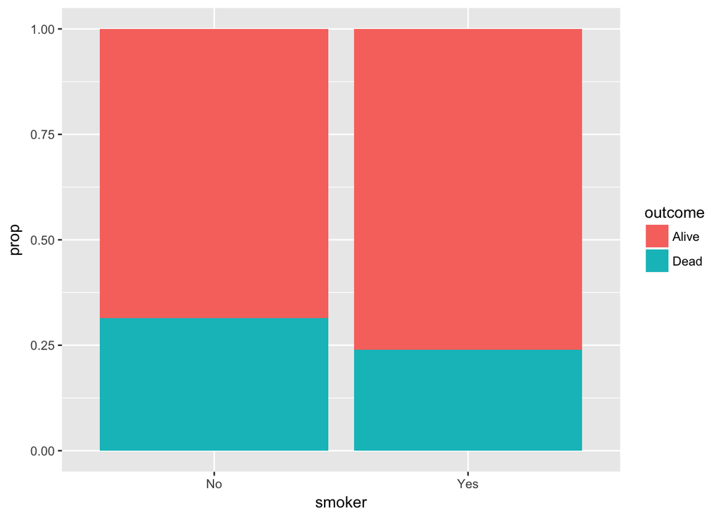

```r
Whickham %>% count(smoker, outcome) %>% group_by(smoker) %>% mutate(prop = n / sum(n)) %>% ggplot(aes(x=smoker, y=prop, fill=outcome)) + geom_col()
```

This does not seem to make sense, because a higher proportion of smokers (443/582 = ~76%) is alive than that of non-smokers (502/732 = ~69%).

### 4. Recode the age variable into an ordered factor with three categories: age <= 44, age > 44 & age <= 64, and age > 64. Now, recreate visualization from above, but facet on your new age factor. What do you see? Does it make sense?

```r
whickham_agegroups <- Whickham %>% mutate(age_group=case_when(age <= 44 ~ '44 and under', age > 44 & age <= 64 ~ '45 to 64', age > 64 ~ 'over 64'))

whickham_agegroups %>% count( smoker , outcome , age_group)
```

```
## # A tibble: 12 x 4
##    smoker outcome age_group        n
##    <fct>  <fct>   <chr>        <int>
##  1 No     Alive   44 and under   327
##  2 No     Alive   45 to 64       147
##  3 No     Alive   over 64         28
##  4 No     Dead    44 and under    12
##  5 No     Dead    45 to 64        53
##  6 No     Dead    over 64        165
##  7 Yes    Alive   44 and under   270
##  8 Yes    Alive   45 to 64       167
##  9 Yes    Alive   over 64          6
## 10 Yes    Dead    44 and under    15
## 11 Yes    Dead    45 to 64        80
## 12 Yes    Dead    over 64         44
```

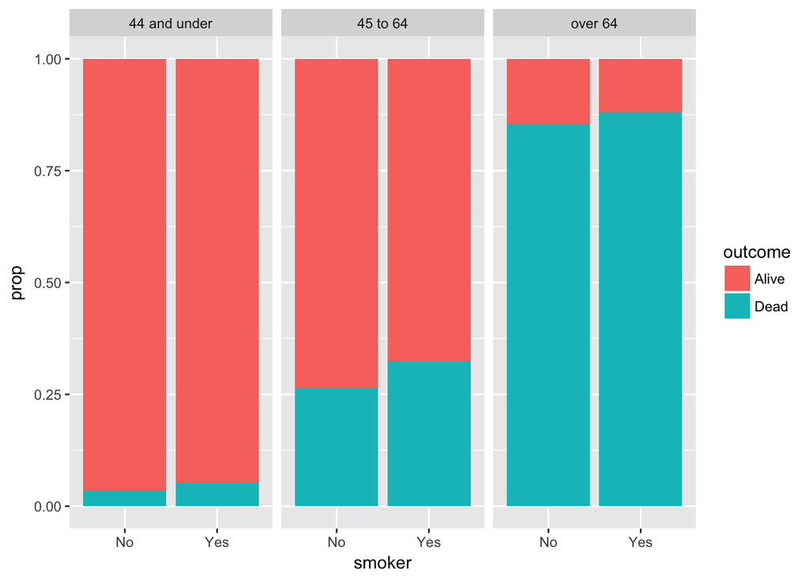

```r
whickham_agegroups %>% count( smoker , outcome , age_group) %>% group_by(smoker, age_group) %>% mutate(prop = n / sum(n)) %>% ggplot(aes(x=smoker, y=prop, fill=outcome)) + geom_col() + facet_grid(. ~ age_group)
```

This makes more sense now, because in each age group, a higher percentage of smokers have died than non-smokers. The reason the totals are misleading is because there are a lot more people in the 44 and under age group. Simpson’s paradox at work.

# Exercise 2

The Central Limit Theorem states that the sampling distribution of sample means is approximately Normal, regardless of the distribution of your population. For this exercise our population distribution will be a Gamma(1,2) distribution, and we’ll show that the sampling distribution of the mean is in fact normally distributed.

### 1. Generate a random sample of size n = 10000 from a gamma(1,2) distribution and plot a histogram or density curve. Use the code below to help you get your sample.

```r
library(tidyverse)
n <- 10000
# look at ?rgamma to read about this function
gamma_samp <- tibble(x = rgamma(n, shape = 1, scale = 2))
```

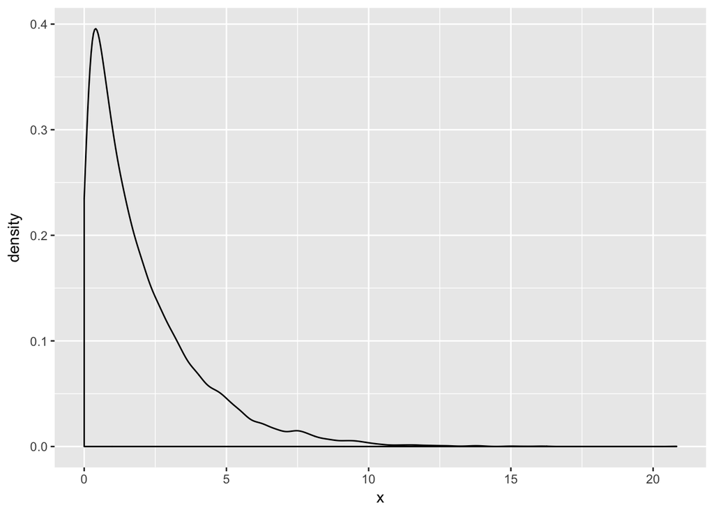

```r
gamma_samp %>% ggplot(aes(x)) + geom_density()
```

### 2. What is the mean and standard deviation of your sample? They should both be close to 2 because for a gamma distribution:

- mean = shape x scale
- variance = shape x scaleˆ2
- mean_samp <- gamma_samp %>% .[[‘x’]] %>% mean()

```r
mean(gamma_samp$x)
```

```
## [1] 2.003314
```

```r
sd(gamma_samp$x)
```

```
## [1] 2.003141
```

### 3. Pretend the distribution of our population of data looks like the plot above. Now take a sample of size n = 30 from a Gamma(1,2) distribution, plot the histogram or density curve, and calculate the mean and standard deviation.

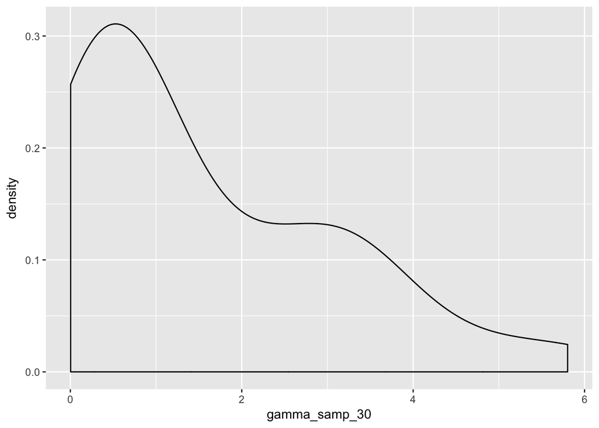

```r
#gamma_samp_30 <- gamma_samp %>% sample_n(30)
#gamma_samp_30 %>% ggplot(aes(x)) + geom_density()

gamma_samp_30 <- rgamma(30, shape = 1, scale = 2)
gamma_samp_30 <- tibble(gamma_samp_30)
gamma_samp_30 %>% ggplot(aes(gamma_samp_30)) + geom_density()
```

```r
mean(gamma_samp_30$gamma_samp_30)
```

```
## [1] 1.554704
```

```r
sd(gamma_samp_30$gamma_samp_30)
```

```
## [1] 1.555371
```

### 4. Take a sample of size n = 30, again from the Gamma(1,2) distribution, calculate the mean, and assign it to a vector named mean_samp. Repeat this 10000 times!!!! The code below might help.

```r
# create a vector with 10000 NAs
mean_samp <- rep(NA, 10000)
# start a loop
for(i in 1:10000) {
  g_samp <- rgamma(30, shape = 1, scale = 2)
  mean_samp[i] <- mean(g_samp)
}
# Convert vector to a tibble
mean_samp <- tibble(mean_samp)
```

### 5. Make a histogram of your collection of means from above (mean_samp).

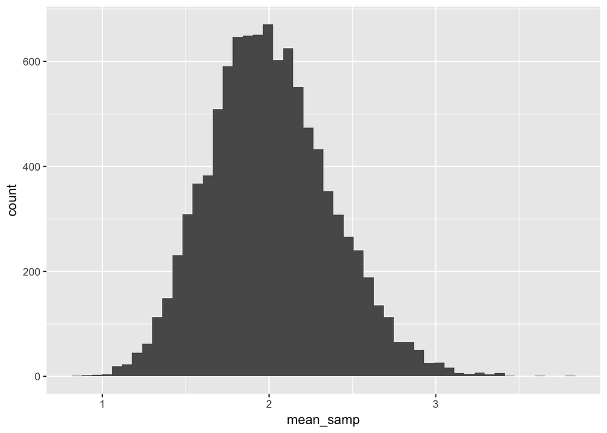

```r
mean_samp %>% ggplot(aes(x=mean_samp)) + geom_histogram(bins=50)
```

### 6. Calculate the mean and standard deviation of all of your sample means.

```r
mean(mean_samp$mean_samp)
```

```
## [1] 2.006753
```

```r
sd(mean_samp$mean_samp)
```

```
## [1] 0.3665371
```

### 7. Did anything surprise you about your answers to #6?

Just as the theorem states, the sampling distribution of sample means is approximately Normal, regardless of the distribution of the population. The gamma(1,2) distribution itself is not Normal.

### 8. According to the Central Limit Theorem, the mean of your sampling distribution should be very close to 2, and the standard deviation of your sampling distribution should be close to σ/√n = 2/√30 = 0.365. Repeat #4-#6, but now with a sample of size n = 300 instead. Do your results match up well with the theorem?

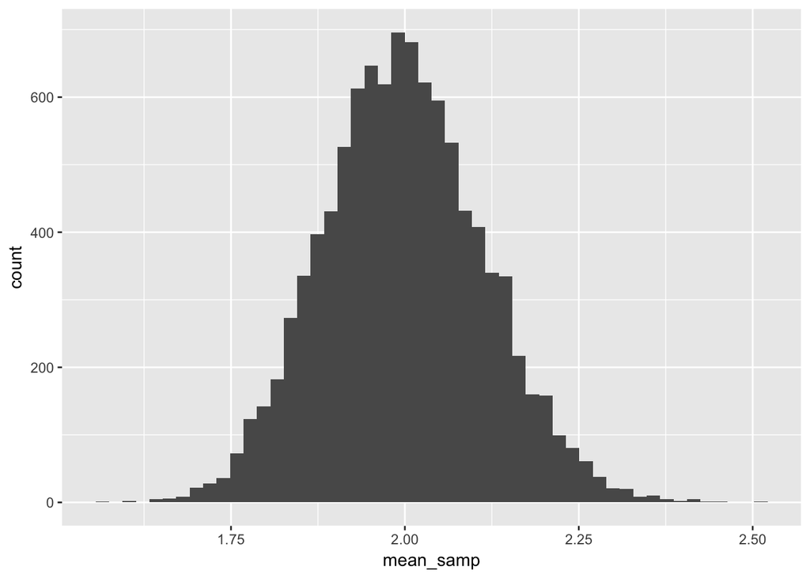

```r
# create a vector with 10000 NAs
mean_samp <- rep(NA, 10000)
# start a loop
for(i in 1:10000) {
  g_samp <- rgamma(300, shape = 1, scale = 2)
  mean_samp[i] <- mean(g_samp)
}
# Convert vector to a tibble
mean_samp <- tibble(mean_samp)

# draw histogram
mean_samp %>% ggplot(aes(x=mean_samp)) + geom_histogram(bins=50)
```

```r
# calculate mean and standard deviation
mean(mean_samp$mean_samp)
```

```
## [1] 1.997844
```

```r
sd(mean_samp$mean_samp)
```

```
## [1] 0.1155893
```

The results match well with the theorem: with larger sample sizes, the mean of their means is approaching 2, and the standard deviation is close to the predicted 2/√300 = 0.1155